# temp-165272438649428790

### Analyzing How The NBA Changed from 2000-2019

By: Luke Kachulis

**Introduction**

The NBA has and continues to be one of the most popular sports leagues in America, and around the world. With a never ending flow of exciting young talent and some of the most loyal fanbases in all of sports the NBA continues to have success attracting fans growing its popularity. One thing that has always stood out to me as a huge NBA fan, is how different the games look now compared to how they looked in old hihglights I watch on YouTube. There are many aspects of today's game that people love, and some things that people dislike. The purpose of this project is to dive deep into NBA team statistics from 2000 to 2019 and analyze how the game has changed in terms of pace, style of play, and more.

The data set used in this project can be found at https://www.kaggle.com/datasets/mharvnek/nba-team-stats-00-to-18 .

**Getting the Data**

To get the data in an organized, easy to read table, I make use of the Pyhton library "Pandas" to read in the csv nicely and store it in a DataFrame. Pandas makes organizing and working with data much easier. You can learn more about pandas [here](https://www.activestate.com/resources/quick-reads/what-is-pandas-in-python-everything-you-need-to-know/#:~:text=Pandas%20is%20an%20open%20source,support%20for%20multi%2Ddimensional%20arrays.). While the data was set up nicely, there was some tidying I needed to do before getting started. The dataset contains data from both the 2019-20 and 2020-21 NBA seasons. As you may remember, both of these seasons were heavily affected by COVID and were shorter than the normal 82 game NBA season. Because of this, I decided to drop those two seasons from the DataFrame and only focus on the seasons 2000-21 through 2018-19. While the last two season could potentially have useful data, it is possible that it could be skewed since not every team played the same amount of games and there were a ton of COVID cases that prevented players from playing. Additionally, these two seasons were played mostly in front of limited capacity crowds or no crowds at all which could make these seasons outliers. Thus, I use pandas to drop those two seasons out of the DataFrame.

```python
import pandas as pd
import numpy as np

tab = pd.read_csv("nba_team_stats_00_to_21.csv")
tab = tab[tab['SEASON'] != '2020-21']
tab = tab[tab['SEASON'] != '2019-20']
tab.head()
```

|  | teamstatspk | TEAM | GP | W | L | WIN% | MIN | PTS | FGM | FGA | ... | REB | AST | TOV | STL | BLK | BLKA | PF | PFD | +/- | SEASON |
| --- | --- | --- | --- | --- | --- | --- | --- | --- | --- | --- | --- | --- | --- | --- | --- | --- | --- | --- | --- | --- | --- |
| 60 | 60 | Milwaukee Bucks | 82 | 60 | 22 | 0.732 | 48.2 | 118.1 | 43.4 | 91.1 | ... | 49.7 | 26.0 | 13.9 | 7.5 | 5.9 | 4.8 | 19.6 | 20.2 | 8.9 | 2018-19 |
| 61 | 61 | Toronto Raptors | 82 | 58 | 24 | 0.707 | 48.5 | 114.4 | 42.2 | 89.1 | ... | 45.2 | 25.4 | 14.0 | 8.3 | 5.3 | 4.5 | 21.0 | 20.5 | 6.1 | 2018-19 |
| 62 | 62 | Golden State Warriors | 82 | 57 | 25 | 0.695 | 48.3 | 117.7 | 44.0 | 89.8 | ... | 46.2 | 29.4 | 14.3 | 7.6 | 6.4 | 3.6 | 21.4 | 19.5 | 6.5 | 2018-19 |
| 63 | 63 | Denver Nuggets | 82 | 54 | 28 | 0.659 | 48.1 | 110.7 | 41.9 | 90.0 | ... | 46.4 | 27.4 | 13.4 | 7.7 | 4.4 | 5.0 | 20.0 | 20.4 | 4.0 | 2018-19 |
| 64 | 64 | Houston Rockets | 82 | 53 | 29 | 0.646 | 48.4 | 113.9 | 39.2 | 87.4 | ... | 42.1 | 21.2 | 13.3 | 8.5 | 4.9 | 4.5 | 22.0 | 20.0 | 4.8 | 2018-19 |

5 rows × 29 columns

The dataset now contains every major statisitical category for every team over the course of the years 2000-2019. While all of these stats are great, for this project we will only be looking at 3-pointer, free throw, and team success stats so I know will drop all of the other columns using pandas.

```python
#Drops unneeded columns
tab=tab.drop(columns=['MIN', 'OREB','DREB','AST','TOV','STL','BLK','BLKA','PF','PFD','+/-'])
tab.head()
```

|  | teamstatspk | TEAM | GP | W | L | WIN% | PTS | FGM | FGA | FG% | 3PM | 3PA | 3P% | FTM | FTA | FT% | REB | SEASON |
| --- | --- | --- | --- | --- | --- | --- | --- | --- | --- | --- | --- | --- | --- | --- | --- | --- | --- | --- |
| 60 | 60 | Milwaukee Bucks | 82 | 60 | 22 | 0.732 | 118.1 | 43.4 | 91.1 | 47.6 | 13.5 | 38.2 | 35.3 | 17.9 | 23.2 | 77.3 | 49.7 | 2018-19 |
| 61 | 61 | Toronto Raptors | 82 | 58 | 24 | 0.707 | 114.4 | 42.2 | 89.1 | 47.4 | 12.4 | 33.8 | 36.6 | 17.7 | 22.0 | 80.4 | 45.2 | 2018-19 |
| 62 | 62 | Golden State Warriors | 82 | 57 | 25 | 0.695 | 117.7 | 44.0 | 89.8 | 49.1 | 13.3 | 34.4 | 38.5 | 16.3 | 20.4 | 80.1 | 46.2 | 2018-19 |
| 63 | 63 | Denver Nuggets | 82 | 54 | 28 | 0.659 | 110.7 | 41.9 | 90.0 | 46.6 | 11.0 | 31.4 | 35.1 | 15.8 | 20.9 | 75.5 | 46.4 | 2018-19 |
| 64 | 64 | Houston Rockets | 82 | 53 | 29 | 0.646 | 113.9 | 39.2 | 87.4 | 44.9 | 16.1 | 45.4 | 35.6 | 19.3 | 24.4 | 79.1 | 42.1 | 2018-19 |

**3 Point Attempts**

Perhaps the most major apparent change over the past 20 seasons has been the usage of the three point shot. As analytics have taken over the game, the simple fact that 3 is greater than 2 has lead to teams taking more three pointers. But just how drastic has this change been? To get a better look, I will now graph the NBA's average 3 point attempts per game over the years to see just how much three point usage has increased year over year. To do this, I will use a library called matplotlib. Matplotlib is a very useful library in python that makes graphing and plotting very easy. To learn more about plotting with matplotlib you can follow this link : https://www.w3schools.com/python/matplotlib_plotting.asp.

```
<function matplotlib.pyplot.show>
```

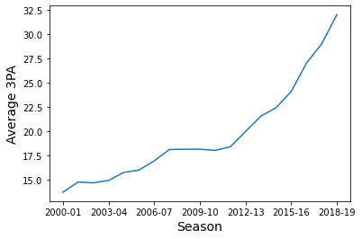

```python
import matplotlib.pyplot as plt
import matplotlib.ticker as mticker
#Get list of seasons
seasons = tab['SEASON'].unique()

#Reverses list to put seasons in chronological order
seasons = np.flip(seasons)

av=[]

#Cycles through seasons and calculates average 3PA per season
for j in seasons:
  y= tab.loc[tab['SEASON'] == j, '3PA']

  tot=0
  for p in y:
    tot=tot+p
  av.append((tot/len(y)))

#plots graph
plt.plot(seasons,av)

plt.xlabel('Season', fontsize=14)
plt.xticks(np.arange(0, len(seasons)+1, 3))
plt.ylabel('Average 3PA', fontsize=14)
plt.show
```

As you can see from the graph, it is clear that there has been a tremendous shift towards the three point shot league-wide over these years. In 2000-01, teams were shooting an average of below 15 three pointers per game. In 2018-19 that average was all the way up over 32 threes per game. There seems to have been a somewhat steady increase at the start then a huge upward trajectory starting around the 2012-13 season that has continued since then.

Now that it has been established that teams have been shooting an increasing number of threes year over year, I want to see if this increase in attempts has effected efficiency at all. To do this I will make a similar plot to the one above but instead graph the average three point percentages over time. My hypothesis is that there will be a slight increase over time but nothing nearly as drastic as the plot off attempts.

```
<function matplotlib.pyplot.show>
```

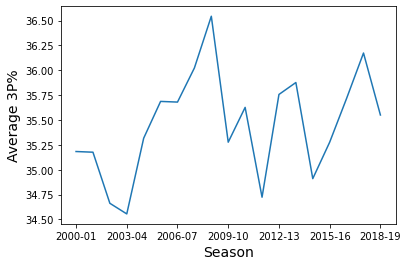

```python
av=[]

#Cycles through seasons and calculates average 3PA per season
for j in seasons:
  y= tab.loc[tab['SEASON'] == j, '3P%']

  tot=0
  for p in y:
    tot=tot+p
  av.append((tot/len(y)))

#plots graph
plt.plot(seasons,av)

plt.xlabel('Season', fontsize=14)
plt.xticks(np.arange(0, len(seasons)+1, 3))
plt.ylabel('Average 3P%', fontsize=14)
plt.show
```

This graph shows that the increased attempts league wide has not had an impact on the shooting percentage. The average three point percentage fluctuated between 34.5% and 36.5% form 2000-2019 with no real pattern or correlation.

The next thing I want to explore is the success of this new strategy of shooting more threes. To get a broad look at this, I will use matplotlib to make a scatter plot of teams win percentage and three point attempts per game. I will use another library called [numpy](https://www.w3schools.com/python/numpy/numpy_intro.asp) to calculate a line of regression to get a better look at the correlation of 3PA to win percentage. For this I will only look at the seasons of 2012-13 to 2018-19 as these were the seasons that this shift toward the three point shot really started to take shape. Based on what we already know, I would make the hypothesis that there would be some sort of positive correlation between 3PA and win percentages.

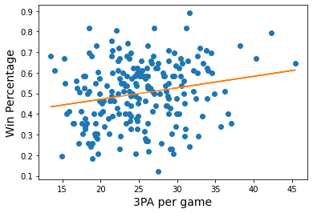

```
m =  0.00558080400736805
```

```python
import numpy as np

seasons_n=['2012-13', '2013-14', '2014-15', '2015-16', '2016-17', '2017-18',
       '2018-19']

threes=[]
winp=[]

#Saves win% and 3PA for teams in range of years
for j in seasons_n:
  y= tab.loc[tab['SEASON'] == j]
  for k in y['3PA']:
    threes.append(k)
  for l in y['WIN%']:
    winp.append(l)


threes=np.asarray(threes)
winp=np.asarray(winp)

#plots points
plt.plot(threes, winp, 'o')

#makes and plots regression
m, b = np.polyfit(threes, winp, 1)
plt.plot(threes, m*threes+b)
plt.xlabel('3PA per game', fontsize=14)
plt.ylabel('Win Percentage', fontsize=14)
plt.show()
print("m = ",m)
```

This graph confirms my hypothesis as it shows that there was a slight positive correlation between 3PA per game and win percentage over the years of 2012-2019 as the leagu-wide shift towards the three point shot really took shape. The regression line had an m of 0.00558080400736805 which means that for every 3PA per game your team has, their winning percentage should go up 0.558080400736805%.

**Pace of Play**

Another aspect of the NBA that is widely considered to have changed is the overall pace of play. The common belief is that teams in today's NBA play at a much faster pace and get shots up much earlier in the shot clock than they did in the early 2000's. The best way to measure pace of play in by analyzing the Field Goal Attempts per game. This is because if you are playing faster, then you are getting more possessions per game and thus, more shots per game.

The first thing to look at when considering the overall pace of play is look at the overall league wide average FGA per game over time similarly to how we examined the 3 point attempts earlier.

```
<function matplotlib.pyplot.show>
```

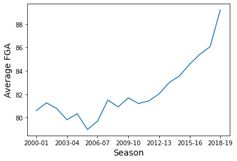

```python
av=[]

#Cycles through seasons and calculates average FGA per season
for j in seasons:
  y= tab.loc[tab['SEASON'] == j, 'FGA']

  tot=0
  for p in y:
    tot=tot+p
  av.append((tot/len(y)))

#plots graph
plt.plot(seasons,av)

plt.xlabel('Season', fontsize=14)
plt.xticks(np.arange(0, len(seasons)+1, 3))
plt.ylabel('Average FGA', fontsize=14)
plt.show
```

Looking at this graph, it is not difficult to see that it is very similar to the graph of league wide 3PA per game we saw above. Both graphs have a huge jump starting around 2012-13. This begs the question: Did 3PA simply increase because the pace of play increased?

**3PA** **Percentage**

To get a more accurate look at how much the three has really taken over the game we need to plot something more in depth than simply 3PA per game. To do this we are gonna take a look at the leagues percentage of shots that are threes. This will give us a better look at whether the three pointer has rreally become more prominant, or if the leeague is simply taking more shots overall.

The first thing we need to do is add a column in our DataFrame that has the teams percentage of shots that are threes. To do this we will once again use pandas to add a column that holds the teams 3PA/FGA.

```python
#Creates new columns "3PA%" that holds the teams percentage of field goals that are threes
tab['3PA%'] = tab['3PA']/tab['FGA']

tab.head()
```

|  | teamstatspk | TEAM | GP | W | L | WIN% | PTS | FGM | FGA | FG% | 3PM | 3PA | 3P% | FTM | FTA | FT% | REB | SEASON | 3PA% |
| --- | --- | --- | --- | --- | --- | --- | --- | --- | --- | --- | --- | --- | --- | --- | --- | --- | --- | --- | --- |
| 60 | 60 | Milwaukee Bucks | 82 | 60 | 22 | 0.732 | 118.1 | 43.4 | 91.1 | 47.6 | 13.5 | 38.2 | 35.3 | 17.9 | 23.2 | 77.3 | 49.7 | 2018-19 | 0.419319 |
| 61 | 61 | Toronto Raptors | 82 | 58 | 24 | 0.707 | 114.4 | 42.2 | 89.1 | 47.4 | 12.4 | 33.8 | 36.6 | 17.7 | 22.0 | 80.4 | 45.2 | 2018-19 | 0.379349 |
| 62 | 62 | Golden State Warriors | 82 | 57 | 25 | 0.695 | 117.7 | 44.0 | 89.8 | 49.1 | 13.3 | 34.4 | 38.5 | 16.3 | 20.4 | 80.1 | 46.2 | 2018-19 | 0.383073 |
| 63 | 63 | Denver Nuggets | 82 | 54 | 28 | 0.659 | 110.7 | 41.9 | 90.0 | 46.6 | 11.0 | 31.4 | 35.1 | 15.8 | 20.9 | 75.5 | 46.4 | 2018-19 | 0.348889 |
| 64 | 64 | Houston Rockets | 82 | 53 | 29 | 0.646 | 113.9 | 39.2 | 87.4 | 44.9 | 16.1 | 45.4 | 35.6 | 19.3 | 24.4 | 79.1 | 42.1 | 2018-19 | 0.519451 |

Now we will graph the league wide average 3PA% over time to see how drastic the 3 point takeover really has been.

```
<function matplotlib.pyplot.show>
```

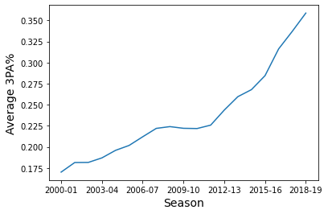

```python
av=[]

#Cycles through seasons and calculates average 3PA% per season
for j in seasons:
  y= tab.loc[tab['SEASON'] == j, '3PA%']

  tot=0
  for p in y:
    tot=tot+p
  av.append((tot/len(y)))

#plots graph
plt.plot(seasons,av)

plt.xlabel('Season', fontsize=14)
plt.xticks(np.arange(0, len(seasons)+1, 3))
plt.ylabel('Average 3PA%', fontsize=14)
plt.show
```

This graph is a much better indication that three pointer truly have had an increased usage over time even when factoring in the increased pace league-wide. Not only are there more threes being attempted, but as this graph proves, the percentage of shot attempts that are threes has also increased.

**Warriors impact on NBA**

The one team that is largely credited with this increase in three point usage and pace is the Golden State Warriors. In the mid to late 2010s, the Warriors were by far the best team in the NBA winning 4 Western Conference Championships, 3 NBA Titles, and setting the single season wins record going 73-9. The NBA is commonly referred to as a "copy-cat" league implying that teams try to replicate the styles and strategies of the most successful teams. I will now test this theory by seeing how the Warriors compared with the rest of the league in pace and three point shot percentage over time. To do this I will use the main DataFrame we have been using to create two new DataFrames: one with only the Warriors teams and one with every team besides the Warriors. I will then plot the three point percent percentages over time for both the warriors and the rest of the league over time.

```
<function matplotlib.pyplot.show>
```

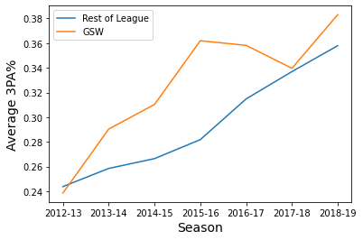

```python
#Creates new DataFrame containing all teams except the Warriors
tab_notGSW = tab.loc[tab['TEAM'] != 'Golden State Warriors']

tab_GSW = tab.loc[tab['TEAM'] == 'Golden State Warriors']

av=[]

#Cycles through seasons and calculates average 3PA% per season for all teams besides Warriors
for j in seasons_n:
  y= tab_notGSW.loc[tab_notGSW['SEASON'] == j, '3PA%']

  tot=0
  for p in y:
    tot=tot+p
  av.append((tot/len(y)))

GSW = []
for j in seasons_n:
  y= tab_GSW.loc[tab_GSW['SEASON'] == j, '3PA%']


  for p in y:
    GSW.append(p)

#plots graph of other teams average
plt.plot(seasons_n,av, label="Rest of League")

plt.plot(seasons_n,GSW, label="GSW")

leg = plt.legend(loc='upper left')

plt.xlabel('Season', fontsize=14)

plt.ylabel('Average 3PA%', fontsize=14)
plt.show
```

This graph shows that there was in fact an effort from the rest of the league to replicate the warriors style of play. The warriors started to play this new style of basktbetball in the 2013-14 season and continued to have a much higher 3PA% than the rest of the league. This gap peaked in 2015-16 when the Warriors had the best record in NBA history. The rest of the NBA then began to become "copy-cats" and the gap between the Warriors and the rest of the league began to shrink.

Now lets take a look at how the NBA adjusted to the Warriors pace.

```
<function matplotlib.pyplot.show>
```

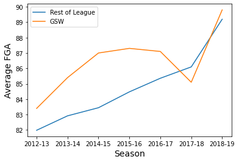

```python
av=[]

#Cycles through seasons and calculates average 3PA% per season for all teams besides Warriors
for j in seasons_n:
  y= tab_notGSW.loc[tab_notGSW['SEASON'] == j, 'FGA']

  tot=0
  for p in y:
    tot=tot+p
  av.append((tot/len(y)))

GSW = []
for j in seasons_n:
  y= tab_GSW.loc[tab_GSW['SEASON'] == j, 'FGA']


  for p in y:
    GSW.append(p)

#plots graph of other teams average
plt.plot(seasons_n,av, label="Rest of League")

plt.plot(seasons_n,GSW, label="GSW")

leg = plt.legend(loc='upper left')

plt.xlabel('Season', fontsize=14)

plt.ylabel('Average FGA', fontsize=14)
plt.show
```

As you can see, the NBA also adjusted to the Warriors high pace as they began to see success. The Warriors even dipped below the league average in 2017-18 after winning their second championship in three years.

**Which teams committed most to new style of play?**

Now lets take a look at every NBA team and how much their 3PA per game increased over time. To do this I will make a bargraph using matplotlib with the increase average 3PA from 2012-13 to 2018-19. A few obstacles here are that 3 franchises have different names in 2018-19 than they did in 2012-13. The Charlotte Bobcats became the Charlotte Hornets, the New Orleans Hornets became the New Orleans Pelicans, and the Los Angeles Clippers became the LA CLippers (they just abbreviated the city). Since there were only three changes over this time period, I am able to handle them each individually. The other 27 teams are cycled through and the differences are calculated, stored, and plotted.

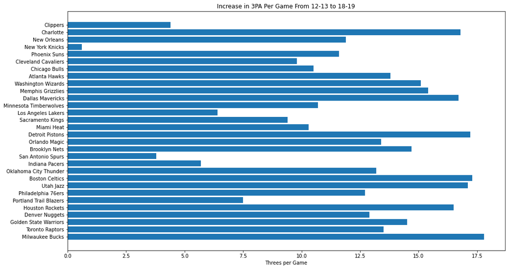

```python
#list of teams with same names in 12-13 and 18-19
teams= ['Milwaukee Bucks', 'Toronto Raptors', 'Golden State Warriors',
       'Denver Nuggets', 'Houston Rockets', 'Portland Trail Blazers',
       'Philadelphia 76ers', 'Utah Jazz', 'Boston Celtics',
       'Oklahoma City Thunder', 'Indiana Pacers',
       'San Antonio Spurs', 'Brooklyn Nets', 'Orlando Magic',
       'Detroit Pistons','Miami Heat',
       'Sacramento Kings', 'Los Angeles Lakers', 'Minnesota Timberwolves',
       'Dallas Mavericks', 'Memphis Grizzlies','Washington Wizards',
        'Atlanta Hawks', 'Chicago Bulls',
       'Cleveland Cavaliers', 'Phoenix Suns', 'New York Knicks']

diffs=[]

#Calculates differnce in 3PA for each team in 2018-19 compared to 2012-13
for j in teams:
  y = tab.loc[tab['TEAM']==j]
  tw = y.loc[y['SEASON'] == '2012-13', '3PA']
  ei = y.loc[y['SEASON'] == '2018-19', '3PA']
  diffs.append(float(ei)-float(tw))

#Adds New Orleans (Name Change)
y = tab.loc[tab['TEAM']=='New Orleans Hornets']
tw = y.loc[y['SEASON'] == '2012-13', '3PA']
y = tab.loc[tab['TEAM']=='New Orleans Pelicans']
ei = y.loc[y['SEASON'] == '2018-19', '3PA']
teams.append("New Orleans")
diffs.append(float(ei)-float(tw))

#Charlotte (Name Change)
y = tab.loc[tab['TEAM']=='Charlotte Bobcats']
tw = y.loc[y['SEASON'] == '2012-13', '3PA']
y = tab.loc[tab['TEAM']=='Charlotte Hornets']
ei = y.loc[y['SEASON'] == '2018-19', '3PA']
teams.append("Charlotte")
diffs.append(float(ei)-float(tw))

#Clippers (City Abbreviation changed in data)
y = tab.loc[tab['TEAM']=='Los Angeles Clippers']
tw = y.loc[y['SEASON'] == '2012-13', '3PA']
y = tab.loc[tab['TEAM']=='LA Clippers']
ei = y.loc[y['SEASON'] == '2018-19', '3PA']
teams.append("Clippers")
diffs.append(float(ei)-float(tw))


fig, ax = plt.subplots(figsize =(16, 9))
plt.barh(teams,diffs)
plt.title('Increase in 3PA Per Game From 12-13 to 18-19')
plt.xlabel('Threes per Game')
```

This graph shows that all 30 teams in the NBA increased the number of threes they shot per game between the 2012-13 and 2018-19 seasons. While they all increased, the significance of the increase varied. As you can see teams such as the Bucks, Celtics, and Pistons had among the biggest increases in the league. Ironically, my own favorite team, the Knicks, had by far the smallest increase in the league which could be a reason that this past decade has been so rough for them.

**Conclusions**

This deep dive into how the NBA has changed from the 2000-01 season through the 2018-19 season has uncovered a few conclusions we can now make. First off, it is clear that the three point shot has indeed taken over the league. Not only have teams increased the number of threes they shoot per game dramatically, but they have also increased the percentage of shots they take that are threes. Additionally, the pace of play has increased throughout the league as teams are getting more and more possessions and attempting more shots per game.  
Moreover there is truth to the belief that the NBA is a "copy-cat" league as we were able to see the Warriors find success in a new style of play and the rest of the league try to replicate that style in response.  
Finally, we were able to see that the level of commitment to this new style of a faster pace and more threes has varied between teams but they have all increased their three point usage in some way. The shift towards this style of play has shown no signs of slowing down and will likely continue to be the main style of the game until a team decides to try a new style and finds success in that style.